# TeX Typesetting in R Graphics: The {xdvir} package

Paul Murrell The University of Auckland

# Where do you look?

[figure not shown]

# How hard can it be?

# How hard can it be?

- Mathematical notation.

# How hard can it be?

- Changes in style (e.g., colour).

# How hard can it be?

- Full justification.

# How hard can it be?

- Hyphenation.

# How hard can it be?

- Typesetting is hard.

# How good is R?

# How good is R?

- Manual line breaks.

# How good is R?

- Ugly math.

# How good is R?

- No full justification.

# How good is R?

- No hyphenation.

# How good is R?

- Inconsistent line spacing.

# How good is R?

- R is pretty bad.

# Three problems

1. **Markup**  
   How to *describe* the text?  
   (e.g., changes in colour)
2. **Typesetting**  
   How to *layout* the text?  
   (e.g., full justification)
3. **Rendering**  
   How to *draw* the text?  
   (in R)

# Two solutions

- ${\rm \LaTeX}$ provides a solution for **Markup** and **Typesetting**.
  - Mathematical notation

    `$\bar z_i$`
  - Colour

    `\textcolor{red}{fitness function}`
  - Full justification by default.
  - Hyphenation by default.

# ${\rm \LaTeX}$ markup

- `text.tex`

  ```
  \documentclass{standalone}
  \usepackage{unicode-math}
  \usepackage{xcolor}
  \begin{document}
  \setmainfont{TeX Gyre Adventor}
  \fontsize{12}{15}
  \selectfont
  \definecolor{Rred}{RGB}{223,83,107}
  \begin{minipage}{3.5in}
  We `move' the original population's mean to a new $\bar z_i$ and
  calculate the average fitness at that new mean phenotype of the
  population to get the adaptive landscape, $\bar W_i$, then we
  combine the population mean and the average fitness to get the
  \textcolor{Rred}{fitness function}.
  \end{minipage}
  \end{document}
  ```

# ${\rm \LaTeX}$ layout

- `text.dvi`

  ```
  x_fnt_def    fontnum=41, ptsize=786432
               fontname=/usr/share/texmf/fonts/opentype/public/tex-gyre/texgyreadventor-regular.otf [0]
  fnt_num_41
  x_glyph      id=56, x=0, y=0
  x_glyph      id=70, x=731382, y=0
  w3           b=327116
  x_glyph      id=113, x=0, y=0
  x_glyph      id=78, x=276038, y=0
  x_glyph      id=80, x=1013711, y=0
  x_glyph      id=87, x=1509163, y=0
  x_glyph      id=70, x=1925186, y=0
  x_glyph      id=114, x=2412774, y=0
  w0
  x_glyph      id=85, x=0, y=0
  x_glyph      id=73, x=266600, y=0
  x_glyph      id=70, x=746324, y=0
  ```

# Glyphs

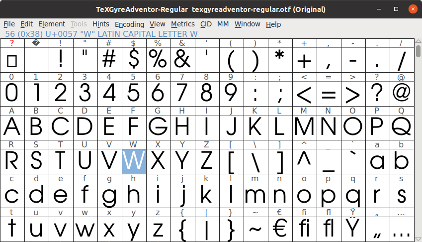

# Three solutions

- From R 4.3.0, we can draw **glyphs**.

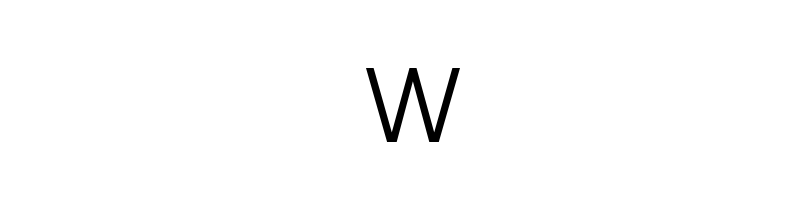

  ```r
  font <- glyphFont(file.path("", "usr", "share", "texmf", "fonts",
                              "opentype", "public", "tex-gyre",
                              "texgyreadventor-regular.otf"),
                    0, "TeX Gyre Adventor", 400, "normal")
  glyph <- glyphInfo(id=56, x=0, y=0, font=1, size=36,
                     glyphFontList(font),
                     width=25, height=30)
  grid.glyph(glyph)
  ```

- This solves the **rendering** problem.

# Four problems

1. **Markup**  
   How to *describe* the text?  
   (e.g., changes in colour)
2. **Typesetting**  
   How to *layout* the text?  
   (e.g., full justification)
3. **Rendering**  
   How to *draw* the text?  
   (in R)
4. **Integration**  
   How to *translate* ${\rm \LaTeX}$ typesetting into R glyphs?

# ${\rm \LaTeX}$ layout

- `text.dvi`

  ```
    0  :  f7 07 01 83 92 c0 1c 3b 00 00 00 00 03  |  .......;.....
   13  :  e8 1d 20 58 65 54 65 58 20 6f 75 74 70  |  .. XeTeX outp
   26  :  75 74 20 32 30 32 34 2e 30 36 2e 32 37  |  ut 2024.06.27
   39  :  3a 31 30 30 39 8b 00 00 00 01 00 00 00  |  :1009........
   52  :  00 00 00 00 00 00 00 00 00 00 00 00 00  |  .............
   65  :  00 00 00 00 00 00 00 00 00 00 00 00 00  |  .............
   78  :  00 00 00 00 00 00 00 ff ff ff ff ef 2e  |  .............
   91  :  70 64 66 3a 70 61 67 65 73 69 7a 65 20  |  pdf:pagesize
  104  :  77 69 64 74 68 20 32 35 39 2e 30 33 39  |  width 259.039
  117  :  70 74 20 68 65 69 67 68 74 20 39 39 2e  |  pt height 99.
  130  :  30 32 33 39 39 70 74 9f 1a c1 05 8d a4  |  02399pt......
  143  :  9c f9 dc 8d 8d 91 b7 ba e1 ef 11 63 6f  |  ...........co
  156  :  6c 6f 72 20 70 75 73 68 20 67 72 61 79  |  lor push gray
  169  :  20 30 92 01 59 00 00 ef 09 63 6f 6c 6f  |   0..Y....colo
  182  :  72 20 70 6f 70 8e 8e a9 63 06 24 8d 91  |  r pop...c.$..
  195  :  b7 ba e1 a1 ef                          |  .....
  ```

# {xdvir}

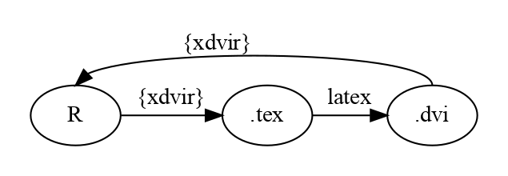

# {xdvir}

- The {xdvir} package allows us to use ${\rm \LaTeX}$ markup to describe text and renders the typeset result in R.

[figure not shown]

  ```r
  library(xdvir)
  grid.latex("Hello \\LaTeX")
  ```

# Mathematical notation

```r
grid.latex("$\\bar z_i$")
```

[output not shown]

# Changes in style

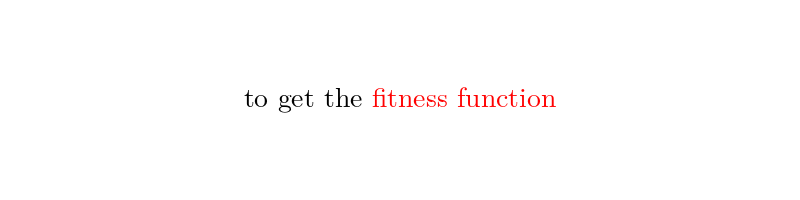

```r
grid.latex("to get the \\color{red} fitness function",
           packages="xcolor")
```

# Full justification and hyphenation

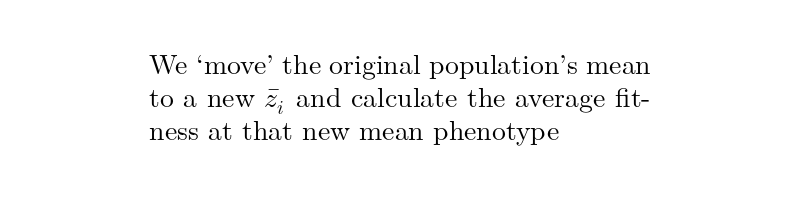

```r
grid.latex("\\begin{minipage}{2.5in}
            We `move' the original population's mean to a new
            $\\bar z_i$ and calculate the average fitness at that
            new mean phenotype
            \\end{minipage}")
```

# What else?

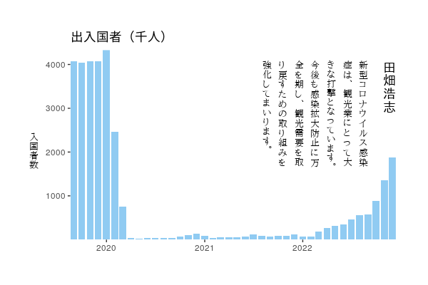

# Limitations

- Not on CRAN.
- Slow.
- Heavy system requirements.
- {grid} interface only.

# Conclusion

- If you care about text on your plots, and you should, then you desperately need:
  - A way to **markup** your text.
  - A way to **typeset** your marked up text.
  - A way to **render** your typeset text.
- The {xdvir} package saves your life by integrating $\LaTeX$ **markup** and **typesetting** with R’s **glyph** **rendering**.

# Acknowledgements

- The first plot is from the Economist.
- The first plot image, plus the eyetracking data, were downloaded from the [MASSVIS project](http://massvis.mit.edu/).
- The second plot is a simplification of an example provided by Marc-Olivier Beausoleil.
- The third plot is a combination of data from the [Statistics Bureau of Japan](https://dashboard.e-stat.go.jp/en/), English text generated by [ChatGPT](https://openai.com/blog/chatgpt), and a Japanese translation by [Google Translate](https://translate.google.com/).